# Yelp Analysis

Martin Kovarik

2019-10-20

## Dataset description:

Yelp is a local business directory service and review site with social networking features. It allows users to give ratings and review businesses. The review is usually short text consisting of few lines with about hundred words. Often, a review describes various dimensions about a business and the experience of user with respect to those dimensions.This dataset is a subset of Yelp’s businesses, reviews, and user data. It was originally put together for the Yelp Dataset Challenge which is a chance for students to conduct research or analysis on Yelp’s data and share their discoveries. In the dataset you’ll find information about businesses across 11 metropolitan areas in four countries. **Source:** [Kaggle](https://www.kaggle.com)

Used Data Sources:

- -rw-r–r– 1 martin martin 138279749 lis 15 2018 business.json
- -rw-r–r– 1 martin martin 5347475638 lis 15 2018 review.json

Loading R packages …

```r
library(jsonlite) # install.packages("jsonlite")
library(tidyverse) # install.packages("tidyverse")
library(dplyr) # install.packages("dplyr")
library(stringi) # install.packages("stringi")
library(maps) # install.packages("maps")
library(ggmap) # install.packages("ggmap")
library(ggplot2) # install.packages("ggplot2")
library(igraph) #  install.packages("igraph")
library(wordcloud) # install.packages("wordcloud")
library(tidytext) # install.packages("tidytext")
library(data.table) # install.packages("data.table")
library(knitr) # install.packages('knitr')
```

Loading business.json dataset …

```r
biz <- stream_in(file("~/Projects/RScripts/Data/business.json"))
##
 Imported 192609 records. Simplifying...
```

### Short EDA of business.json dataset

## Top 10 Categories of Business

```r
table(trimws(strsplit(unique(biz$categories), ",") %>%
                                unlist())) %>% as.data.frame() %>% arrange(desc(Freq)) %>%
  rename(Category=Var1) %>% top_n(n = 10, wt = Freq) %>%
ggplot(aes(x=Category, y=Freq)) +
  geom_bar(stat="identity", fill="steelblue") +
  geom_text(aes(label=Freq), vjust=1.6, color="white", size=2.8) +
  theme_minimal() + theme(axis.text.x = element_text(angle = 90, hjust = 1)) +
  ggtitle("Top 10 Categories of Business") + xlab("Category") + ylab("Count")
```

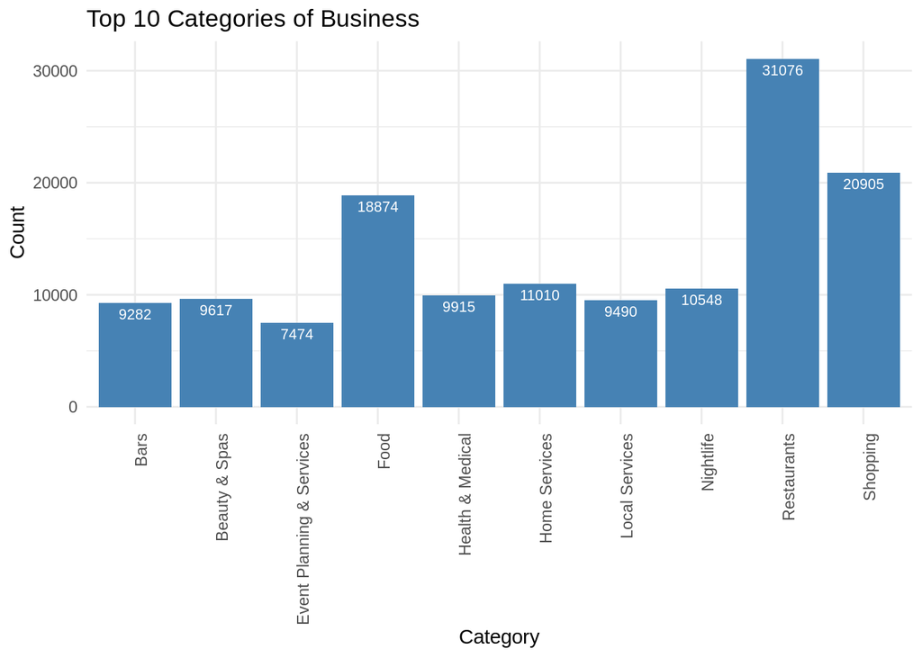

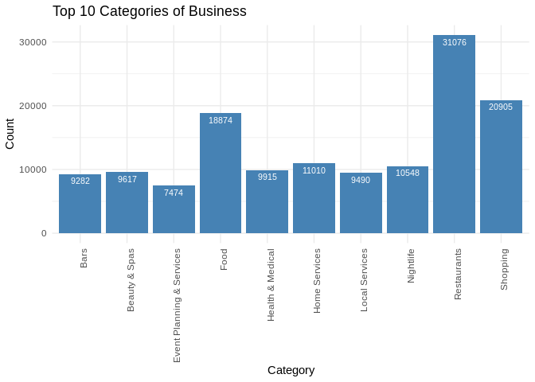

## Stars distribution for Restaurants

```r
biz %>% filter(grepl("restaurants", tolower(categories))) %>%
  group_by(stars) %>% summarise(Count=n()) %>% ungroup() %>%
  ggplot(aes(x=stars, y=Count)) +
    geom_bar(stat='identity', colour="white", fill = fillColor) +
    geom_text(aes(x = stars, y = 1, label = paste0("(",round(Count/1e3)," K )",sep="")),
              hjust=0, vjust=.5, size = 4, colour = 'white',
              fontface = 'bold') +
    labs(x = 'Stars', y = 'Count of stars Category',
         title = 'Distribution of Stars Rating for Restaurants only') +
    coord_flip() +
    theme_bw()
```

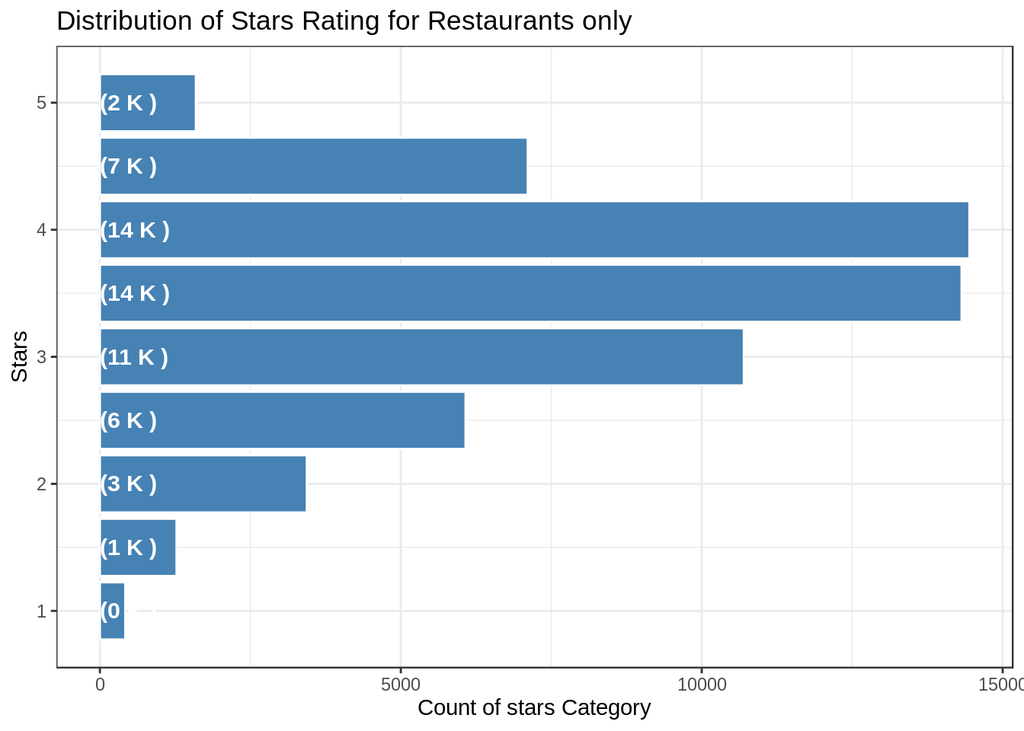

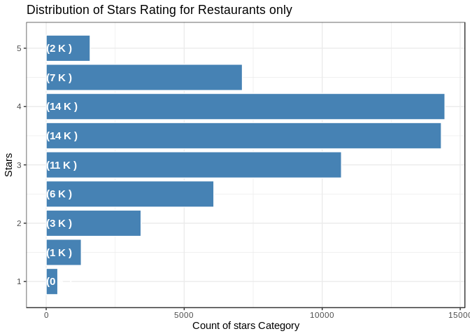

## Map of restaurants only

```r
restaurants <- biz %>% filter(grepl("restaurants", tolower(categories)))
qmplot(x = longitude, y=latitude, data=restaurants,
       geom = "point", color = is_open)
```

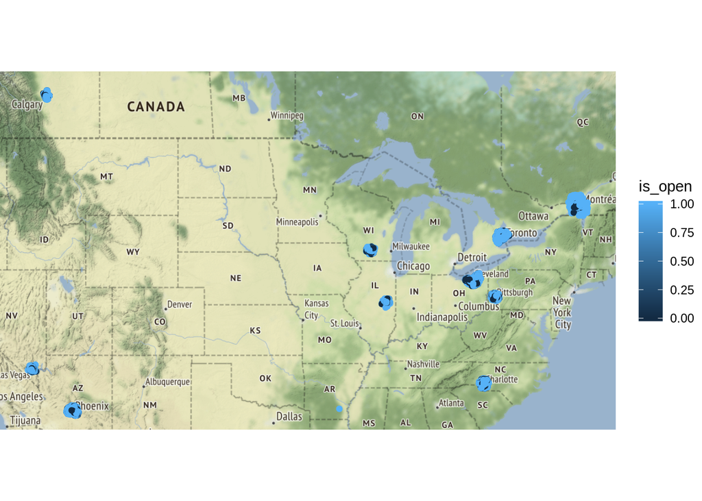

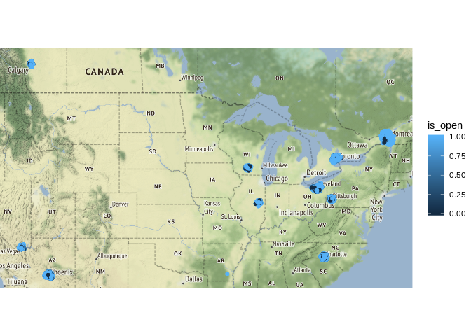

## Average Stars less than 3 group by city

```r
kable(biz %>% filter(grepl("restaurants", tolower(categories))) %>%
  group_by(city) %>%
  summarise(stars_avg=mean(stars, na.rm=T)) %>% ungroup() %>%
  filter(stars_avg < 3) %>% arrange(desc(stars_avg)) %>% top_n(10, stars_avg),
  caption = "Stars less than 3 group by city - top 10"
  )
```

Stars less than 3 group by city - top 10

| city | stars_avg |
| --- | --- |
| Tallmadge | 2.975000 |
| Savoy | 2.968750 |
| Penn Hills | 2.964286 |
| Maple Heights | 2.958333 |
| Munhall | 2.958333 |
| Rocky View | 2.950000 |
| Stouffville | 2.948276 |
| Locust | 2.944444 |
| North Versailles | 2.940000 |
| Balzac | 2.916667 |

## Top Ten Cities with the most Business parties mentioned in Yelp

```r
biz %>%
  group_by(city) %>%
  summarise(Count = n()) %>%
  arrange(desc(Count)) %>%
  ungroup() %>%
  mutate(City = reorder(city,Count)) %>%
  head(10) %>%
  ggplot(aes(x = City,y = Count)) +
  geom_bar(stat='identity',colour="white", fill = fillColor) +
  geom_text(aes(x = City, y = 1, label = paste0("(",round(Count/1e3)," K )",sep="")),
            hjust=0, vjust=.5, size = 4, colour = 'white',
            fontface = 'bold') +
  labs(x = 'City', y = 'Count of Reviews',
       title = 'Top Ten Cities with the most Business parties in Yelp') +
  coord_flip() +
  theme_bw()
```

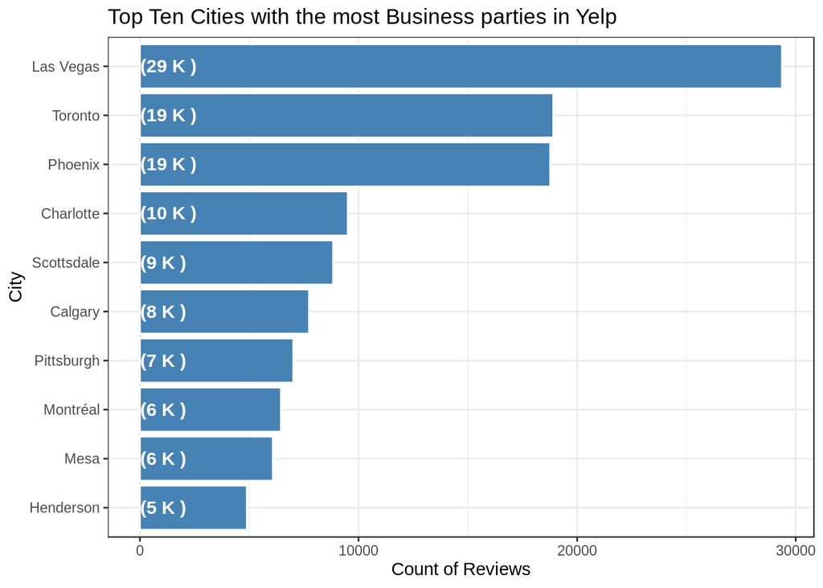

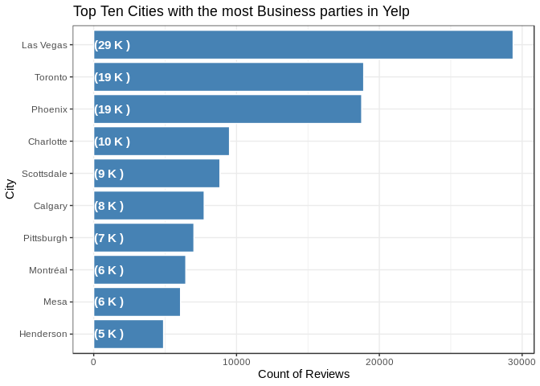

## Top most reviewed businesses

```r
kable(
  biz %>% group_by(name) %>%
  summarise(ReviewCount=sum(review_count, na.rm=T),
            AvgStar=round(mean(stars, na.rm=T), 2)) %>%
  arrange(desc(ReviewCount)) %>% ungroup() %>%
  top_n(10, ReviewCount),
  caption = "Top 10 most reviewed businesses"
)
```

Top 10 most reviewed businesses

| name | ReviewCount | AvgStar |
| --- | --- | --- |
| Starbucks | 23880 | 3.26 |
| McDonald’s | 14328 | 2.04 |
| Hash House A Go Go | 11534 | 3.67 |
| Chipotle Mexican Grill | 9266 | 2.92 |
| Mon Ami Gabi | 8348 | 4.00 |
| Bacchanal Buffet | 8339 | 4.00 |
| Buffalo Wild Wings | 7308 | 2.78 |
| In-N-Out Burger | 6800 | 4.06 |
| Wicked Spoon | 6708 | 3.50 |
| Panera Bread | 6489 | 2.74 |

### Naive Bayes Classifier - PySpark

```r
htmltools::includeHTML('~/Projects/RScripts/Data/Spark_Yelp.html')
```

# Yelp - building star rating classifier

Followring simple excercise demonstrates star rating classifier, particularly Naive Bayes.

```python
from pyspark.sql import SparkSession
```

```python
spark = SparkSession.builder.appName('yelp').getOrCreate()
```

```python
biz = spark.read.json('d:/O2_CaseStudy/business.json')
```

```python
review = spark.read.json('d:/O2_CaseStudy/review.json')
```

### Average star rating less than 3 by cities

```python
# Sum by Agg
group_data = biz.groupBy("city")
result = group_data.agg({'stars':'avg'})
result = result.orderBy(result['avg(stars)'].desc())
result = result.filter(result['avg(stars)'] < 3.0).toPandas()
result.columns = ['City', 'AvgStars']
```

```python
result.head(5)
```

|  | City | AvgStars |
| --- | --- | --- |
| 0 | Dorval | 2.989691 |
| 1 | Brookpark | 2.968750 |
| 2 | Greenfield Park | 2.950000 |
| 3 | Rexdale | 2.900000 |
| 4 | St-Leonard | 2.900000 |

```python
import pandas as pd
import numpy as np
import seaborn as sns
import matplotlib.pyplot as plt
%matplotlib inline
```

### Top 20 results of Average star rating less than 3 by cities - graphical interpretation with Seaborn

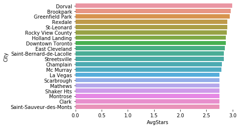

```python
sns.barplot(data=result.head(20), x='AvgStars', y='City')
sns.despine(left = True, bottom = True)
plt.show()
```

## NLP for Earl of Sandwich - Naive Bayes classification for stars rating

```python
from pyspark.ml.feature import (Tokenizer, StopWordsRemover, CountVectorizer,
                                IDF, StringIndexer)
import numpy as np
```

```python
eos = np.array(biz.filter(biz['name'] == 'Earl of Sandwich').select('business_id').collect())
```

```python
eos
```

```
array([['DEBqmgxv2yhJ93LqGpKltg'],
       ['fE7x3Ui2mzdwdfJnd7r_1g'],
       ['DkYS3arLOhA8si5uUEmHOw'],
       ['Ffhe2cmRyloz3CCdRGvHtA'],
       ['3fT1kcQ-MVEImGHa3hll5w']], dtype='<U22')
```

```python
earl_of_sandwich = review.filter("business_id in ('DEBqmgxv2yhJ93LqGpKltg','fE7x3Ui2mzdwdfJnd7r_1g','DkYS3arLOhA8si5uUEmHOw','Ffhe2cmRyloz3CCdRGvHtA','3fT1kcQ-MVEImGHa3hll5w')")
```

```python
earl_of_sandwich.groupBy('stars').count().show()
```

```
+-----+-----+
|stars|count|
+-----+-----+
|  1.0|  141|
|  4.0| 1889|
|  3.0|  704|
|  2.0|  246|
|  5.0| 2875|
+-----+-----+
```

```python
earl_of_sandwich.columns
```

```
['business_id',
 'cool',
 'date',
 'funny',
 'review_id',
 'stars',
 'text',
 'useful',
 'user_id']
```

```python
from pyspark.sql.functions import length
```

```python
earl_of_sandwich = earl_of_sandwich.withColumn('length', length(earl_of_sandwich['text']))
```

```python
from pyspark.sql.functions import format_number
```

```python
earl_of_sandwich.columns
```

```
['business_id',
 'cool',
 'date',
 'funny',
 'review_id',
 'stars',
 'text',
 'useful',
 'user_id',
 'length']
```

```python
earl_of_sandwich.printSchema()
```

```
root
 |-- business_id: string (nullable = true)
 |-- cool: long (nullable = true)
 |-- date: string (nullable = true)
 |-- funny: long (nullable = true)
 |-- review_id: string (nullable = true)
 |-- stars: double (nullable = true)
 |-- text: string (nullable = true)
 |-- useful: long (nullable = true)
 |-- user_id: string (nullable = true)
 |-- length: integer (nullable = true)
```

```python
tokenizer = Tokenizer(inputCol='text', outputCol='token_text')
stop_words_remove = StopWordsRemover(inputCol='token_text', outputCol='stop_token')
count_vec = CountVectorizer(inputCol='stop_token', outputCol='c_vec')
idf = IDF(inputCol='c_vec', outputCol='tf_idf')
stars_class = StringIndexer(inputCol='stars', outputCol='label')
```

```python
from pyspark.ml.feature import VectorAssembler
```

```python
clean_up = VectorAssembler(inputCols=['tf_idf', 'length'], outputCol='features')
```

```python
from pyspark.ml.classification import NaiveBayes
```

```python
nb = NaiveBayes()
```

```python
from pyspark.ml import Pipeline
```

```python
data_prep_pipe = Pipeline(stages=[stars_class, tokenizer,
                                 stop_words_remove, count_vec, idf,
                                 clean_up])
```

```python
cleaner = data_prep_pipe.fit(earl_of_sandwich)
```

```python
clean_data = cleaner.transform(earl_of_sandwich)
```

```python
clean_data = clean_data.select('label', 'features')
```

```python
clean_data.show()
```

```
+-----+--------------------+
|label|            features|
+-----+--------------------+
|  0.0|(26923,[4,9,12,10...|
|  4.0|(26923,[0,2,17,54...|
|  4.0|(26923,[0,1,3,18,...|
|  2.0|(26923,[11,34,42,...|
|  0.0|(26923,[1,2,11,15...|
|  3.0|(26923,[10,16,79,...|
|  0.0|(26923,[0,4,8,12,...|
|  4.0|(26923,[0,4,12,16...|
|  1.0|(26923,[0,1,5,7,8...|
|  2.0|(26923,[1,15,16,3...|
|  0.0|(26923,[1,2,13,14...|
|  1.0|(26923,[0,1,5,13,...|
|  1.0|(26923,[1,2,4,5,7...|
|  1.0|(26923,[2,5,15,32...|
|  1.0|(26923,[0,1,13,16...|
|  2.0|(26923,[1,2,8,15,...|
|  3.0|(26923,[1,3,6,7,8...|
|  4.0|(26923,[8,76,192,...|
|  0.0|(26923,[0,1,14,32...|
|  2.0|(26923,[1,19,46,7...|
+-----+--------------------+
only showing top 20 rows
```

```python
training, test = clean_data.randomSplit([0.7, 0.3])
```

```python
star_detector = nb.fit(training)
```

```python
earl_of_sandwich.printSchema()
```

```
root
 |-- business_id: string (nullable = true)
 |-- cool: long (nullable = true)
 |-- date: string (nullable = true)
 |-- funny: long (nullable = true)
 |-- review_id: string (nullable = true)
 |-- stars: double (nullable = true)
 |-- text: string (nullable = true)
 |-- useful: long (nullable = true)
 |-- user_id: string (nullable = true)
 |-- length: integer (nullable = true)
```

```python
test_results = star_detector.transform(test)
```

```python
test_results.show()
```

```
+-----+--------------------+--------------------+--------------------+----------+
|label|            features|       rawPrediction|         probability|prediction|
+-----+--------------------+--------------------+--------------------+----------+
|  0.0|(26923,[0,3,6,12,...|[-2257.7283223200...|[0.99994534358914...|       0.0|
|  0.0|(26923,[0,4,8,12,...|[-3737.3251404332...|[1.0,7.1426571945...|       0.0|
|  0.0|(26923,[2,3,12,18...|[-1901.3512612624...|[0.99999993472454...|       0.0|
|  1.0|(26923,[0,1,3,19,...|[-838.12138669477...|[1.51381796237448...|       1.0|
|  1.0|(26923,[0,1,5,7,8...|[-5549.0814089650...|[1.87614452513813...|       2.0|
|  1.0|(26923,[0,1,13,16...|[-2203.5453882083...|[0.99868472518438...|       0.0|
|  1.0|(26923,[1,2,4,5,7...|[-1539.4068126819...|[3.25173402052072...|       1.0|
|  1.0|(26923,[1,2,5,7,8...|[-738.54945014640...|[0.99884944171548...|       0.0|
|  1.0|(26923,[1,5,13,14...|[-1651.7869631722...|[0.99999401430747...|       0.0|
|  1.0|(26923,[2,13,14,2...|[-917.79732534409...|[0.99999999973216...|       0.0|
|  2.0|(26923,[0,1,9,26,...|[-736.64200705096...|[1.98525737964752...|       1.0|
|  2.0|(26923,[0,2,23,25...|[-589.82813173996...|[3.12359199387119...|       2.0|
|  2.0|(26923,[0,3,4,6,1...|[-1688.9314635073...|[1.87654893410657...|       1.0|
|  2.0|(26923,[0,5,6,8,9...|[-3854.5283646035...|[2.61250782177923...|       2.0|
|  2.0|(26923,[0,6,16,19...|[-3002.0533264990...|[9.77645796191807...|       4.0|
|  2.0|(26923,[0,7,10,14...|[-1084.5078013946...|[5.13002741706445...|       3.0|
|  2.0|(26923,[1,2,8,15,...|[-815.19197363089...|[1.68862086323902...|       2.0|
|  2.0|(26923,[1,3,18,19...|[-1287.5641668896...|[0.57856625679915...|       0.0|
|  2.0|(26923,[1,15,16,3...|[-562.68916273900...|[3.01638682913337...|       3.0|
|  2.0|(26923,[1,26,34,3...|[-1597.8205752650...|[6.01112765330051...|       1.0|
+-----+--------------------+--------------------+--------------------+----------+
only showing top 20 rows
```

```python
from pyspark.ml.evaluation import MulticlassClassificationEvaluator
```

```python
acc_eval = MulticlassClassificationEvaluator()
```

```python
acc = acc_eval.evaluate(test_results)
```

```python
print('ACC of NB Model')
print(acc)
```

```
ACC of NB Model
0.501903565387439
```